# Clase 5 - Visualizando información geográfica

Stadia ofrece varios estilos de mapa base, que pueden revisarse en su [sitio web](https://stadiamaps.com/). Entre ellos:

- `terrain` (usado por defecto)
- `toner` (monocromático)
- `toner_lite` (versión alternativa de toner, de menos contraste visual)
- `watercolor` (hay que probarlo para apreciarlo, pero digamos que es artístico)

Cuando descargamos un mapa que vamos a usar de base para visualizar datos siempre es una buena idea elegir una opción en escala de grises, sin colores que compitan contra los datos que proyectaremos.

Probamos entonces descargar una monocromática, pasando una vez mas nuestra bbox y agregamdo el parámetro `maptype = "stamen_toner_lite"`:

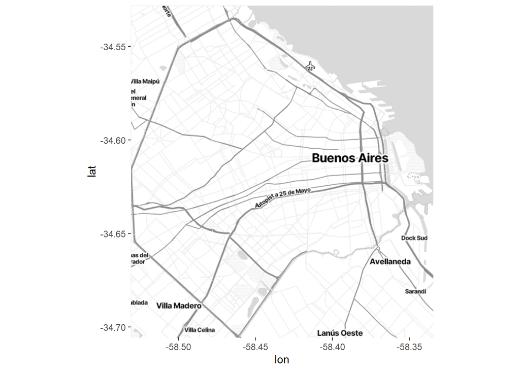

```r
mapa_CABA_toner <- get_stadiamap(bbox_ggmap,
                          maptype = "stamen_toner_lite",
                          zoom = 12)

ggmap(mapa_CABA_toner)
```

Y por fin, para mostrar nuestros propios datos, como hicimos antes con ggplot… la verdad es que no hay mucho esfuerzo extra! Podemos usar casi el mismo código. Sólo necesitamos recordar dos cosas:

- en vez de comenzar con `ggplot()`, comenzamos la visualización con `ggmap(mapa_CABA_toner)`
- donde usamos `geom_sf()`, agregamos el parámetro `inherit.aes = FALSE`.

El segundo punto es necesario por que `ggmap()` usa un sistema particular de coordenadas de referencia, que pueden causar problemas si son distintas a la de los datos geográficos que muestra `geom_sf()`. Al agregar ese parámetro, se le indica a `geom_sf()` que no intente usar (“heredar”) las coordenadas de `ggmap()`, y listo.

A intentarlo:

[output not shown]

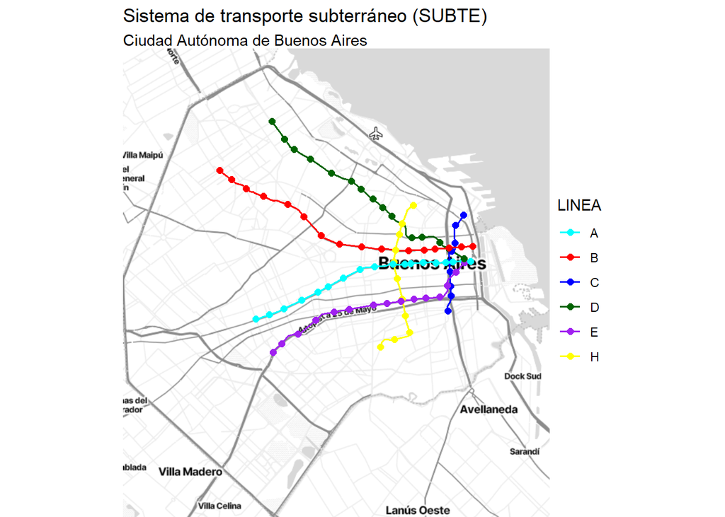

```r
ggmap(mapa_CABA_toner) +
  geom_sf(data = subte_lineas,
          aes(color = LINEA),
          linewidth = 0.7,
          inherit.aes = FALSE) +
  geom_sf(data = subte_estaciones,
          aes(color = LINEA),
          size = 2,
          inherit.aes = FALSE) +
  scale_color_manual(values = color_lineas) +
  theme_void() +
  labs(title = "Sistema de transporte subterráneo (SUBTE)",
       subtitle = "Ciudad Autónoma de Buenos Aires")
```

La función `get_stadiamap()` descarga tiles de mapa desde los servidores de Stadia y las combina en una imagen que `ggmap()` usa como fondo. El parámetro `inherit.aes = FALSE` en las capas geom_sf() es crucial: le dice a ggplot que no use las coordenadas del mapa base para estas geometrías, sino sus propias coordenadas espaciales.

En esta ocasión no usamos la capa de radios, como si habíamos visualizado en el ejemplo con `ggplot`. ¿Porqué creen que fue? ¿Cómo mostrarían la capa de radios?

### Explorando otros estilos de Stadia Maps

Stadia ofrece varios estilos heredados de Stamen, cada uno optimizado para diferentes tipos de visualización:

*Stamen Toner*: alto contraste, excelente para datos destacados

```r
mapa_toner <- get_stadiamap(bbox_ggmap,
                           maptype = "stamen_toner",
                           zoom = 12)
```

```
## ℹ © Stadia Maps © Stamen Design © OpenMapTiles © OpenStreetMap contributors.
```

[output not shown]

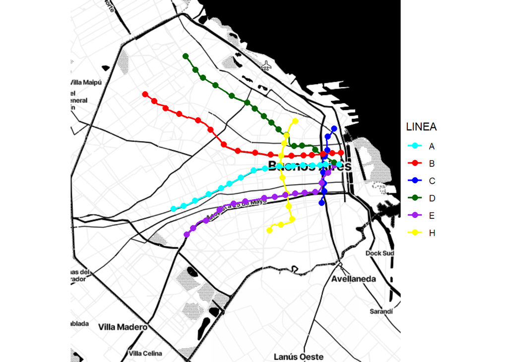

```r
ggmap(mapa_toner) +
  geom_sf(data = subte_lineas,
          aes(color = LINEA),
          linewidth = 0.8,
          inherit.aes = FALSE) +
  geom_sf(data = subte_estaciones,
          aes(color = LINEA),
          size = 2.5,
          inherit.aes = FALSE) +
  scale_color_manual(values = color_lineas) +
  theme_void()
```

*Stamen Watercolor*: estilo artístico, ideal para presentaciones especiales

```r
mapa_watercolor <- get_stadiamap(bbox_ggmap,
                                maptype = "stamen_watercolor",
                                zoom = 12)
```

```
## ℹ © Stadia Maps © Stamen Design © OpenMapTiles © OpenStreetMap contributors.
```

[output not shown]

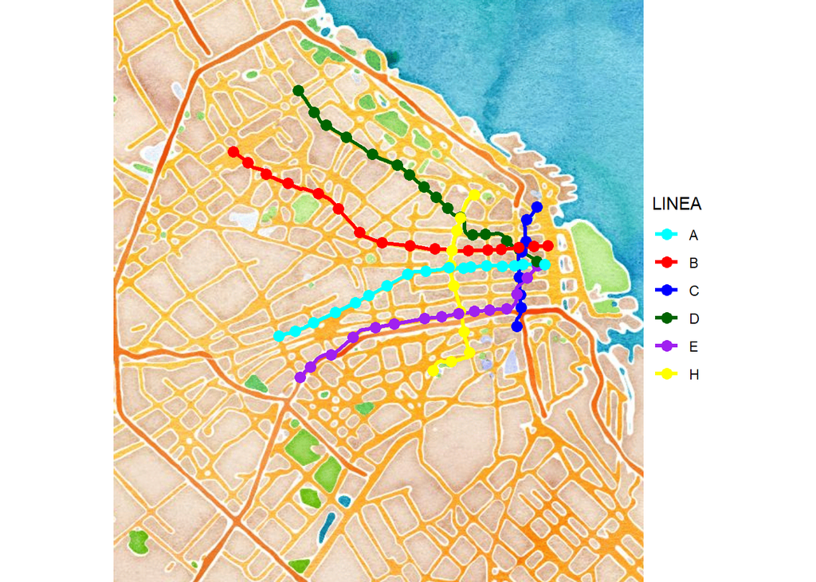

```r
ggmap(mapa_watercolor) +
  geom_sf(data = subte_lineas,
          aes(color = LINEA),
          linewidth = 1.2,
          inherit.aes = FALSE) +
  geom_sf(data = subte_estaciones,
          aes(color = LINEA),
          size = 3,
          inherit.aes = FALSE) +
  scale_color_manual(values = color_lineas) +
  theme_void()
```

- *stamen_toner*: alto contraste en blanco y negro, excelente para datos que necesitan destacar
- *stamen_watercolor*: estilo artístico y único, ideal para presentaciones donde queremos “wow factor”

## Mapas interactivos

Los mapas estáticos son ideales para reportes impresos o presentaciones, porque comunican un mensaje “cerrado” y directo. En cambio, cuando compartimos nuestro trabajo en formato digital (HTML, dashboards, sitios web), los mapas interactivos habilitan una experiencia mucho más rica: zoom, panorámica, popups y control de capas.

En `R`, el paquete `leaflet` es el estándar de facto para construir mapas interactivos. Lo interesante es que trabaja por capas, igual que `ggplot2`: primero definimos un lienzo (el mapa) y luego sumamos elementos (líneas, puntos, polígonos) con funciones específicas.

### Mapas interactivos con leaflet

Desde R es fácil proyectar nuestros datos sobre mapas interactivos, usando el paquete `leaflet`.

Lo activamos con:

```r
library(leaflet)
```

`Leaflet` trabaja exclusivamente con el sistema de coordenadas WGS84 (EPSG:4326), el mismo que usan GPS y mapas web. Si nuestros datos están en otro sistema de coordenadas, debemos transformarlos:

```r
subte_lineas_wgs84 <- st_transform(subte_lineas, 4326)
subte_estaciones_wgs84 <- st_transform(subte_estaciones, 4326)
radios_wgs84 <- st_transform(radios, 4326)
```

En Buenos Aires, el color “oficial” de cada línea es parte de su identidad visual. Por eso conviene fijar una paleta consistente.

```r
# Colores oficiales del subte de Buenos Aires
pal <- colorFactor(palette = c("cyan3", "red", "blue", "green3", "purple", "yellow2"),
                   domain = c("A", "B", "C", "D", "E", "H"))
```

### Nuestro primer mapa interactivo

El uso de leaflet es similar al de ggplot; uno toma un dataframe y lo muestra mediante capas que exponen distintos aspectos de la información. Empezamos con un mapa base (tiles) y sumamos capas: (1) líneas del subte con addPolylines() y (2) estaciones con addCircleMarkers()

```r
leaflet() %>%
  addProviderTiles(providers$CartoDB.Positron) %>%
  addPolylines(data = subte_lineas_wgs84,
               color = ~pal(LINEA),
               weight = 4,
               opacity = 0.6) %>%
  addCircleMarkers(data = subte_estaciones_wgs84,
                   color = ~pal(LINEA),
                   fillColor = ~pal(LINEA),
                   radius = 6,
                   fillOpacity = 0.6)
```

[interactive chart not shown]

### Agregando popups

Una de las grandes ventajas de leaflet son los popups que aparecen al hacer clic. Empezemos con algo simple:

```r
leaflet() %>%
  addProviderTiles(providers$CartoDB.Positron) %>%
    addPolylines(data = subte_lineas_wgs84,
               color = ~pal(LINEA),
               weight = 4,
               opacity = 0.6) %>%
  addCircleMarkers(data = subte_estaciones_wgs84,
                   color = ~pal(LINEA),
                   fillColor = ~pal(LINEA),
                   radius = 6,
                   fillOpacity = 0.6,
                    popup = ~paste("Estación:", ESTACION))
```

[interactive chart not shown]

Podemos hacer los popups más atractivos con un poco de HTML básico:

```r
leaflet() %>%
  addProviderTiles(providers$CartoDB.Positron) %>%
      addPolylines(data = subte_lineas_wgs84,
               color = ~pal(LINEA),
               weight = 4,
               opacity = 0.6,
               popup = ~paste("<b>Línea", LINEA, "</b>")) %>%
  addCircleMarkers(data = subte_estaciones_wgs84,
                   color = ~pal(LINEA),
                   fillColor = ~pal(LINEA),
                   radius = 6,
                   fillOpacity = 0.6,
                    popup = ~paste("<b>", ESTACION, "</b><br>",
                                 "Línea:", LINEA))
```

[interactive chart not shown]

### Control básico de capas

Podemos permitir que los usuarios activen y desactiven diferentes elementos:

```r
leaflet() %>%
  addProviderTiles(providers$CartoDB.Positron) %>%
  addPolylines(data = subte_lineas_wgs84,
               color = ~pal(LINEA),
               weight = 4,
               opacity = 0.6,
               popup = ~paste("<b>Línea", LINEA, "</b>"),
               group = "Líneas") %>%  # ¡Agregá esto!
  addCircleMarkers(data = subte_estaciones_wgs84,
                   color = ~pal(LINEA),
                   fillColor = ~pal(LINEA),
                   radius = 6,
                   fillOpacity = 0.6,
                   popup = ~paste("<b>", ESTACION, "</b><br>",
                                 "Línea:", LINEA),
                   group = "Estaciones") %>%  # ¡Y esto!
  # Control de capas
  addLayersControl(
    overlayGroups = c("Líneas", "Estaciones"),
    options = layersControlOptions(collapsed = FALSE)
  )
```

[interactive chart not shown]

También podemos ofrecer diferentes estilos de mapa base:

```r
mapa_final <- leaflet() %>%
  # Diferentes opciones de mapa base
  addProviderTiles(providers$CartoDB.Positron, group = "Claro") %>%
  addProviderTiles(providers$CartoDB.DarkMatter, group = "Oscuro") %>%
  addProviderTiles(providers$Esri.WorldStreetMap, group = "Calles") %>%
  # Datos del subte
  addPolylines(data = subte_lineas_wgs84,
               color = ~pal(LINEA),  # Cambié esto
               weight = 4,
               opacity = 0.8,
               popup = ~paste("<b>Línea", LINEA, "</b>"),
               group = "Subte") %>%
  addCircleMarkers(data = subte_estaciones_wgs84,
                   color = ~pal(LINEA),  # Cambié esto
                   fillColor = ~pal(LINEA),  # Agregué esto
                   radius = 8,
                   fillOpacity = 0.8,
                   popup = ~paste("<b>", ESTACION, "</b><br>Línea:", LINEA),
                   group = "Subte") %>%
  # Control de capas
  addLayersControl(
    baseGroups = c("Claro", "Oscuro", "Calles"),
    overlayGroups = c("Subte"),
    options = layersControlOptions(collapsed = FALSE)
  )

# Mostrar el mapa
mapa_final
```

[interactive chart not shown]

#### Exportando mapas interactivos a HTML

Una de las grandes ventajas de leaflet es que podemos guardar nuestros mapas como archivos HTML independientes para compartir:

```r
library(htmlwidgets)

# Guardar el mapa como archivo HTML
saveWidget(mapa_final,
          file = "mapa_subte_interactivo.html",
          selfcontained = TRUE)
```

`selfcontained = TRUE` hace que el archivo HTML incluya todas las dependencias necesarias, creando un archivo único que se puede compartir sin problemas. El archivo resultante puede abrirse en cualquier navegador web y mantiene toda la funcionalidad interactiva.

## Resumiendo: ¿cuándo usar cada enfoque?

El ecosistema de mapas en R nos ofrece múltiples caminos, cada uno con sus fortalezas:

*Para mapas estáticos*

- ggmap con Stadia Maps: calidad excepcional, estilos únicos diseñados para visualización de datos, requiere API key gratuita
- maptiles: sin registros, múltiples proveedores, ideal para casos rápidos

*Para mapas interactivos*

- leaflet: el estándar de facto, interactividad completa, popups, control de capas, y fácil exportación a HTML

*¿Por qué evitar OpenStreetMap como proveedor principal?*

1. Velocidad: Los servidores de OSM son más lentos que CartoDB o Esri
2. Calidad visual: Los tiles de OSM no están optimizados para visualización de datos
3. Carga en servidores: OSM es un proyecto colaborativo sin fines de lucro; usar alternativas comerciales reduce la carga

*¿Cuándo usar mapas estáticos vs interactivos?*

- Estáticos: reportes PDF, presentaciones impresas, cuando el mensaje debe ser directo y sin distracciones
- Interactivos: reportes HTML, dashboards, sitios web, cuando queremos que el usuario explore los datos

*Consejos para leaflet*

- Empezar simple: primero el mapa básico, después agregar popups y controles
- Los grupos permiten que el usuario controle qué ver
- Exportar a HTML permite compartir mapas sin necesidad de R

*Sugerencia para mostrar los radios censales*

En esta ocasión no usamos la capa de radios en los primeros ejemplos, como sí habíamos visualizado en los ejemplos anteriores con ggplot básico. ¿Por qué creen que fue? La respuesta está en la *legibilidad*: cuando agregamos un mapa base detallado, mostrar también los límites de todos los radios censales puede crear sobrecarga visual que dificulta ver nuestros datos principales (las líneas y estaciones del subte).

Para profundizar en estas técnicas, recomendamos revisar el capítulo [“Draw maps”](https://socviz.co/maps.html) en *Data Visualization - A practical introduction*, y explorar [“la galería de ejemplos de leaflet”](https://rstudio.github.io/leaflet/) para descubrir funcionalidades más avanzadas como clustering de puntos, mapas de calor, y animaciones temporales.